# Assignment 2: Spatial Analysis and Visualization

## Part 3: Bring Your Own Data Analysis

### Your Analysis

**Your Task:**

1. **Find and load additional data**
   - Document your data source
   - Check and standardize the CRS
   - Provide basic summary statistics

```r
# Load your additional dataset
library(httr)
library(jsonlite)

tree=st_read("C:/Users/wensh/Desktop/MUSA5080/week-04/data/ppr_tree_inventory_2024/ppr_tree_inventory_2024.shp")
parkl=st_read("C:/Users/wensh/Desktop/MUSA5080/week-04/data/PPR_Program_Sites.geojson")
park_proj=parkl%>%st_transform(3365)
tree_proj=tree%>%st_transform(3365)
summary(park_proj)
```

```
    OBJECTID       PARK_NAME          DPP_ASSET_ID  PROGRAM_TYPE
 Min.   : 807.0   Length:171         Min.   :   4   Length:171
 1st Qu.: 993.5   Class :character   1st Qu.:1826   Class :character
 Median :1036.0   Mode  :character   Median :1891   Mode  :character
 Mean   :1027.6                      Mean   :1795
 3rd Qu.:1078.5                      3rd Qu.:1952
 Max.   :1121.0                      Max.   :3479
  SITE_CLASS          BUILDING             GYM            LABEL_NUMBER
 Length:171         Length:171         Length:171         Length:171
 Class :character   Class :character   Class :character   Class :character
 Mode  :character   Mode  :character   Mode  :character   Mode  :character



   COMMENTS         DATA_SOURCE                 geometry
 Length:171         Length:171         POINT        :171
 Class :character   Class :character   epsg:3365    :  0
 Mode  :character   Mode  :character   +proj=lcc ...:  0
```

```r
summary(tree_proj)
```

```
    objectid       tree_name            tree_dbh           year
 Min.   :     1   Length:151713      Min.   :  -3.00   Length:151713
 1st Qu.: 37929   Class :character   1st Qu.:   4.00   Class :character
 Median : 75857   Mode  :character   Median :  10.00   Mode  :character
 Mean   : 75857                      Mean   :  13.09
 3rd Qu.:113785                      3rd Qu.:  20.00
 Max.   :151713                      Max.   :1118.00
                                     NA's   :16
     loc_y           loc_x                 geometry
 Min.   :39.87   Min.   :-75.28   POINT        :151713
 1st Qu.:39.95   1st Qu.:-75.20   epsg:3365    :     0
 Median :39.98   Median :-75.17   +proj=lcc ...:     0
 Mean   :39.99   Mean   :-75.16
 3rd Qu.:40.03   3rd Qu.:-75.14
 Max.   :40.14   Max.   :-74.96
```

**Questions to answer:** - What dataset did you choose and why?

I choose both tree and park data in Philadelphia because I want to study if different tracts have equal access to green spaces

- What is the data source and date?

  Both of them are from Opendataphilly, tree data is from 2024 while park data is from 2022
- How many features does it contain?

  there are 151,713 features in tree data and 171 features in park data
- What CRS is it in? Did you need to transform it?

  Both of the CRS are WGS84 at first and I transform it to espg 3365
2. **Pose a research question**

Write a clear research statement that your analysis will answer.

**Do minority and low income census tracts have the same access to green spaces and enjoy same tree canopy as others?**

3. **Conduct spatial analysis**

Use at least TWO spatial operations to answer your research question.

**Required operations (choose 2+):** - Buffers - Spatial joins - Spatial filtering with predicates - Distance calculations - Intersections or unions - Point-in-polygon aggregation

**Your Task:**

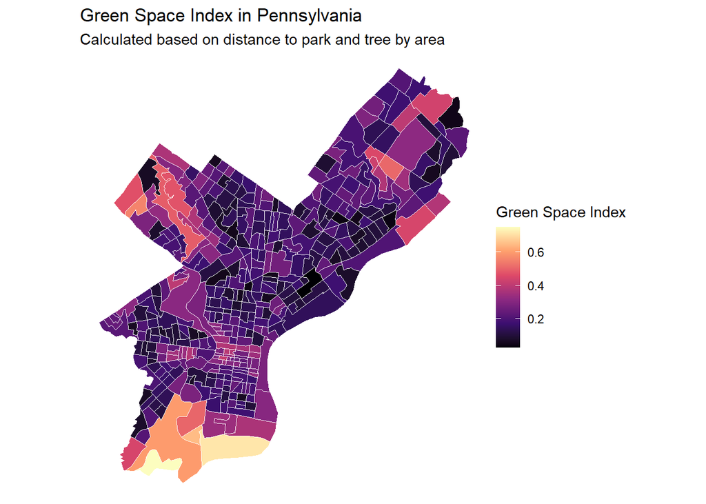

```r
# Your spatial analysis
#get philly census data
philly=get_acs(
  geography = "tract",
  state = "PA",
  county = "101",
  year = 2023,
  survey = "acs5",
  variables =c(population="DP02_0018",age="DP05_0023",income="DP03_0062"),
  geometry = TRUE,
  output="wide"
)
#reproject census data
philly_project=philly%>%
  st_transform(3365)
#spatial join census data with tree counts
philly_tree = philly_project%>%
  mutate(tree_count = lengths(st_contains(., tree_proj)))

#calculate the distance between tract and parks
tract_center=st_centroid(philly_project)
dist_park <- tract_center %>%
  mutate(
    dis_to_tract = apply(
      st_distance(tract_center, park_proj),
      1,
      min
    ) *0.000189
  )

#merge tree counts and distance to park
dist_final_philly = dist_park%>%
  st_drop_geometry()%>%
  select(GEOID,dis_to_tract)
final_philly = philly_tree%>%
  left_join(dist_final_philly,by="GEOID")

#calculate tree per area in census tract
final_philly = final_philly%>%
  mutate(area=st_area(geometry))%>%
  mutate(tree_per=as.numeric(tree_count/area))

#normalize both distance to park and tree per area
normalize_to_0_1 <- function(vec) {
  min_val <- min(vec, na.rm = TRUE)
  max_val <- max(vec, na.rm = TRUE)
  normalized_vec <- (vec - min_val) / (max_val - min_val)
  return(normalized_vec)
}

#calculate the final index (park 75% weight and tree 25% weight)
final_philly=final_philly%>%
  mutate(normalize_tree=normalize_to_0_1(tree_per))%>%
  mutate(normalize_park=normalize_to_0_1(dis_to_tract))%>%
  mutate(index=0.75*normalize_park+0.25*normalize_tree)

#map the results
ggplot(final_philly) +
  geom_sf(aes(fill = index), color = "white")+
  scale_fill_viridis_c(
    name = "Green Space Index",
    option = "magma"
  ) +
  labs(
    title = "Green Space Index in Pennsylvania",
    subtitle = "Calculated based on distance to park and tree by area"
  ) +
  theme_void()
```

**Analysis requirements:** - Clear code comments explaining each step - Appropriate CRS transformations - Summary statistics or counts - At least one map showing your findings - Brief interpretation of results (3-5 sentences)

**Your interpretation:**

## Finally - A few comments about your incorporation of feedback!

First I remove the extra instruction text in my homework such as the submission requirement in the end, I also remove the [] in my answer.

Second, I used round() function to make my table look cleaner